# DMP_H2

Sundance

2024-11-05

```r
library(brms)
library(dplyr)
library(ggplot2)
library(bayesplot)
library(psych)
library(car)
library(lmtest)
library(MASS)
```

一、描述性统计

```r
h2_data <- read.csv("D:\\mycodelife\\workshop\\course_task\\Salary Data.csv")
```

检视数据

```r
summary(h2_data)
```

```
##  Current.Salary   Beginning.Salary Previous.Experience   Education
##  Min.   : 16350   Min.   : 9750    Min.   :  0.00      Min.   : 8.00
##  1st Qu.: 23325   1st Qu.:12000    1st Qu.: 17.75      1st Qu.:12.00
##  Median : 27825   Median :14250    Median : 60.50      Median :12.00
##  Mean   : 33633   Mean   :16939    Mean   : 95.61      Mean   :13.22
##  3rd Qu.: 35775   3rd Qu.:16575    3rd Qu.:139.25      3rd Qu.:15.00
##  Max.   :103750   Max.   :60000    Max.   :460.00      Max.   :19.00
```

```r
describe(h2_data)
```

```
##                     vars   n     mean       sd  median  trimmed     mad   min
## Current.Salary         1 100 33632.60 17289.55 27825.0 30215.12 8517.54 16350
## Beginning.Salary       2 100 16938.60  8347.83 14250.0 15107.25 3335.85  9750
## Previous.Experience    3 100    95.61   105.48    60.5    76.01   78.58     0
## Education              4 100    13.22     2.72    12.0    13.32    4.45     8
##                        max range  skew kurtosis      se
## Current.Salary      103750 87400  2.24     5.47 1728.96
## Beginning.Salary     60000 50250  2.63     8.08  834.78
## Previous.Experience    460   460  1.55     2.08   10.55
## Education               19    11 -0.12    -0.30    0.27
```

二、绘制因变量和自变量的散点图

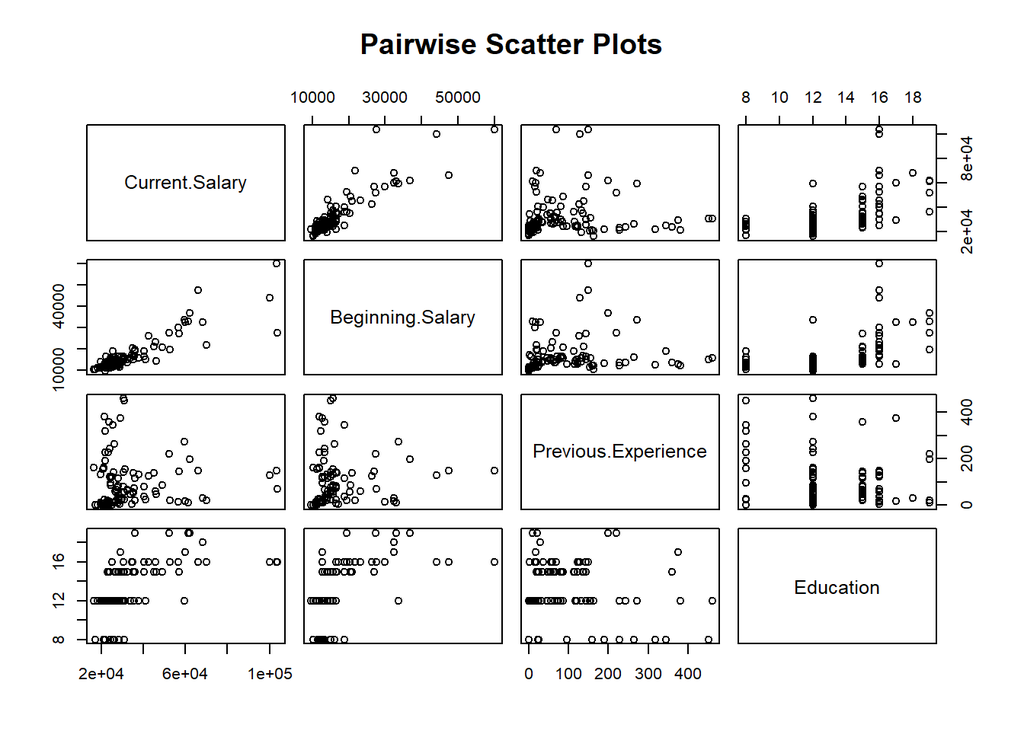

```r
pairs(h2_data, main = "Pairwise Scatter Plots")
```

该图能反映Current Salary与其他变量的关联

三、给出模型形式

1.构建模型

```r
model <- lm(h2_data$Current.Salary ~ h2_data$Beginning.Salary + h2_data$Previous.Experience + h2_data$Education, data = h2_data)
```

检视模型

```r
summary(model)
```

```
##
## Call:
## lm(formula = h2_data$Current.Salary ~ h2_data$Beginning.Salary +
##     h2_data$Previous.Experience + h2_data$Education, data = h2_data)
##
## Residuals:
##    Min     1Q Median     3Q    Max
## -21900  -3583   -577   1418  49548
##
## Coefficients:
##                               Estimate Std. Error t value Pr(>|t|)
## (Intercept)                 -4139.2377  4203.3582  -0.985   0.3272
## h2_data$Beginning.Salary        1.7302     0.1138  15.203   <2e-16 ***
## h2_data$Previous.Experience   -10.9071     7.7710  -1.404   0.1637
## h2_data$Education             719.1221   351.7339   2.045   0.0436 *
## ---
## Signif. codes:  0 '***' 0.001 '**' 0.01 '*' 0.05 '.' 0.1 ' ' 1
##
## Residual standard error: 7791 on 96 degrees of freedom
## Multiple R-squared:  0.8031, Adjusted R-squared:  0.7969
## F-statistic: 130.5 on 3 and 96 DF,  p-value: < 2.2e-16
```

2.是否满足Gauss-Markov假设

（1）检查线性性是否成立

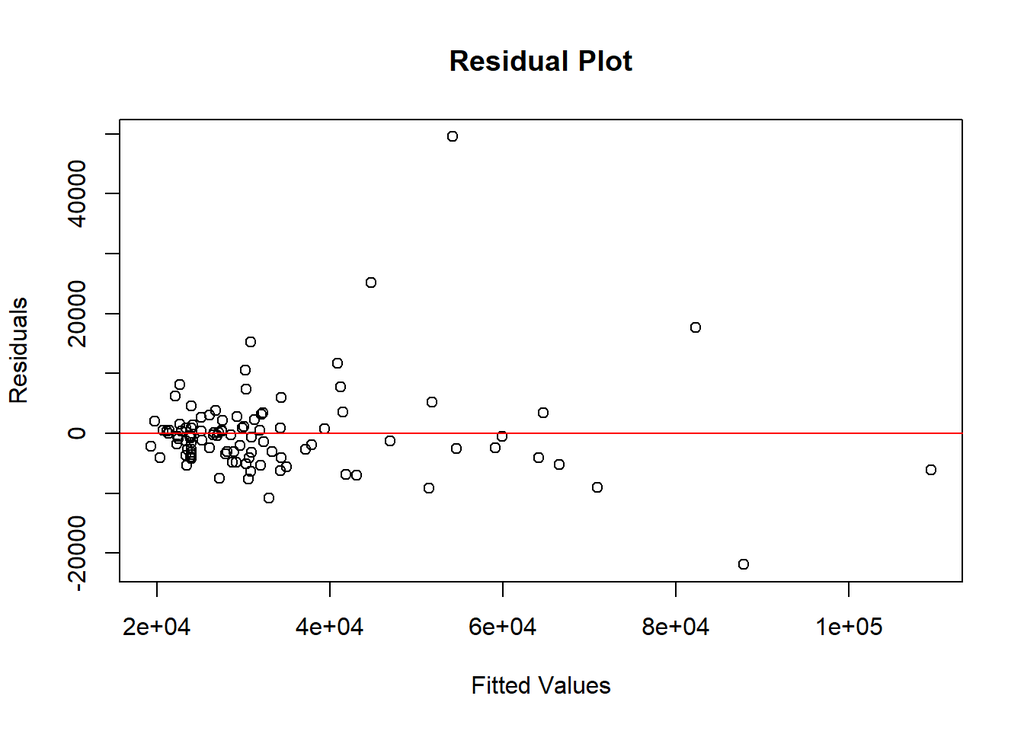

```r
# 绘制残差图
plot(model$fitted.values, model$residuals, main = "Residual Plot", xlab = "Fitted Values", ylab = "Residuals")
abline(h = 0, col = "red")
```

如图，图中残差在 0 附近随机分布，则线性性假设可能成立。

（2）检查是否存在多重共线性

```r
vif(model)
```

```
##    h2_data$Beginning.Salary h2_data$Previous.Experience
##                    1.472233                    1.095796
##           h2_data$Education
##                    1.490282
```

VIF大于1且没有超过5，说明具有相关性且不存在多重共线性

（3）检查同方差性

```r
bptest(model)
```

```
##
##  studentized Breusch-Pagan test
##
## data:  model
## BP = 7.2635, df = 3, p-value = 0.06396
```

p>0.05，可能满足同方差假设

（4）检查残差的独立性

```r
dwtest(model)
```

```
##
##  Durbin-Watson test
##
## data:  model
## DW = 1.6712, p-value = 0.04704
## alternative hypothesis: true autocorrelation is greater than 0
```

残差偏离2，可能存在残差相关性

（5）残差的正态性

```r
shapiro.test(model$residuals)
```

```
##
##  Shapiro-Wilk normality test
##
## data:  model$residuals
## W = 0.73658, p-value = 4.198e-12
```

p<0.05，说明残差不满足正态性

综上所述，不满足Gauss-Markov假设，因此OLS估计是有偏的，需要采取其他估计

四、采用Robust回归

前文假定误差协方差矩阵满足$\sigma^2I$，但是经过检验可能为$\sigma^2\Sigma$，因此需要采用其他估计方法。

1.M估计

M估计通过调整回归系数估计的损失函数，使模型对离群点不敏感。常见的损失函数包括Huber损失（对小残差使用平方惩罚，对大残差使用线性惩罚）和Tukey损失。

```r
model_rlm <- rlm(h2_data$Current.Salary ~ h2_data$Beginning.Salary + h2_data$Previous.Experience + h2_data$Education, psi = psi.huber)  # 使用Huber损失
summary(model_rlm)
```

```
##
## Call: rlm(formula = h2_data$Current.Salary ~ h2_data$Beginning.Salary +
##     h2_data$Previous.Experience + h2_data$Education, psi = psi.huber)
## Residuals:
##       Min        1Q    Median        3Q       Max
## -18716.17  -2480.96    -31.55   2146.05  51884.32
##
## Coefficients:
##                             Value      Std. Error t value
## (Intercept)                 -1694.7814  2287.9118    -0.7408
## h2_data$Beginning.Salary        1.6732     0.0619    27.0098
## h2_data$Previous.Experience    -7.2503     4.2298    -1.7141
## h2_data$Education             502.3916   191.4508     2.6241
##
## Residual standard error: 3576 on 96 degrees of freedom
```

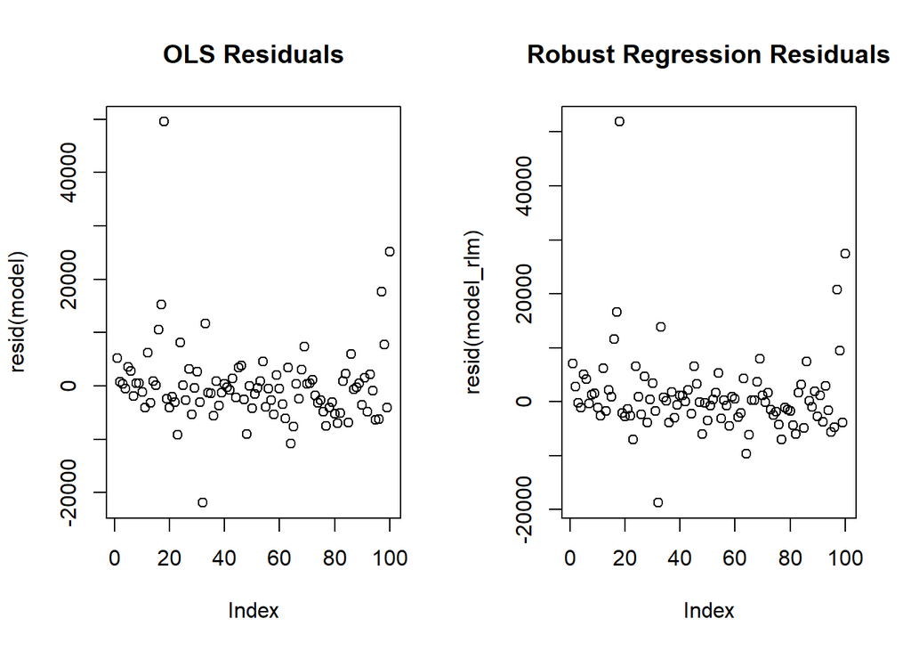

```r
# 绘制残差图比较
par(mfrow = c(1, 2))
plot(resid(model), main = "OLS Residuals")
plot(resid(model_rlm), main = "Robust Regression Residuals")
```

可见，没有明显的区别。

2.加权最小二乘回归

```r
weights <- 1 / abs(h2_data$Current.Salary - predict(lm(h2_data$Current.Salary ~ h2_data$Beginning.Salary + h2_data$Previous.Experience + h2_data$Education))) # 权重示例

# 使用lm()函数指定权重
model_wls <- lm(h2_data$Current.Salary ~ h2_data$Beginning.Salary + h2_data$Previous.Experience + h2_data$Education, weights = weights)
summary(model_wls)
```

```
##
## Call:
## lm(formula = h2_data$Current.Salary ~ h2_data$Beginning.Salary +
##     h2_data$Previous.Experience + h2_data$Education, weights = weights)
##
## Weighted Residuals:
##     Min      1Q  Median      3Q     Max
## -135.13  -53.42  -18.60   40.72  227.03
##
## Coefficients:
##                               Estimate Std. Error t value Pr(>|t|)
## (Intercept)                 -3.331e+03  9.089e+02  -3.665 0.000406 ***
## h2_data$Beginning.Salary     1.680e+00  5.048e-02  33.281  < 2e-16 ***
## h2_data$Previous.Experience -9.797e+00  2.143e+00  -4.572 1.44e-05 ***
## h2_data$Education            6.883e+02  8.193e+01   8.401 3.99e-13 ***
## ---
## Signif. codes:  0 '***' 0.001 '**' 0.01 '*' 0.05 '.' 0.1 ' ' 1
##
## Residual standard error: 66.92 on 96 degrees of freedom
## Multiple R-squared:  0.9479, Adjusted R-squared:  0.9463
## F-statistic: 582.7 on 3 and 96 DF,  p-value: < 2.2e-16
```

效果非常好，所有系数均显著。说明采用加权最小二乘回归效果较好。

五、采用逐步回归

1.前向选择

```r
null_model <- lm(h2_data$Current.Salary ~ 1, data = h2_data)
stepwise_model_forward <- step(model,
                               scope = list(lower = null_model, upper = model),
                               direction = "forward")
```

```
## Start:  AIC=1796.06
## h2_data$Current.Salary ~ h2_data$Beginning.Salary + h2_data$Previous.Experience +
##     h2_data$Education
```

```r
summary(stepwise_model_forward)
```

```
##
## Call:
## lm(formula = h2_data$Current.Salary ~ h2_data$Beginning.Salary +
##     h2_data$Previous.Experience + h2_data$Education, data = h2_data)
##
## Residuals:
##    Min     1Q Median     3Q    Max
## -21900  -3583   -577   1418  49548
##
## Coefficients:
##                               Estimate Std. Error t value Pr(>|t|)
## (Intercept)                 -4139.2377  4203.3582  -0.985   0.3272
## h2_data$Beginning.Salary        1.7302     0.1138  15.203   <2e-16 ***
## h2_data$Previous.Experience   -10.9071     7.7710  -1.404   0.1637
## h2_data$Education             719.1221   351.7339   2.045   0.0436 *
## ---
## Signif. codes:  0 '***' 0.001 '**' 0.01 '*' 0.05 '.' 0.1 ' ' 1
##
## Residual standard error: 7791 on 96 degrees of freedom
## Multiple R-squared:  0.8031, Adjusted R-squared:  0.7969
## F-statistic: 130.5 on 3 and 96 DF,  p-value: < 2.2e-16
```

2.后向选择

```r
stepwise_model_backward <- step(model, direction = "backward")
```

```
## Start:  AIC=1796.06
## h2_data$Current.Salary ~ h2_data$Beginning.Salary + h2_data$Previous.Experience +
##     h2_data$Education
##
##                               Df  Sum of Sq        RSS    AIC
## <none>                                      5.8270e+09 1796.1
## - h2_data$Previous.Experience  1 1.1958e+08 5.9466e+09 1796.1
## - h2_data$Education            1 2.5372e+08 6.0807e+09 1798.3
## - h2_data$Beginning.Salary     1 1.4029e+10 1.9856e+10 1916.7
```

```r
summary(stepwise_model_backward)
```

```
##
## Call:
## lm(formula = h2_data$Current.Salary ~ h2_data$Beginning.Salary +
##     h2_data$Previous.Experience + h2_data$Education, data = h2_data)
##
## Residuals:
##    Min     1Q Median     3Q    Max
## -21900  -3583   -577   1418  49548
##
## Coefficients:
##                               Estimate Std. Error t value Pr(>|t|)
## (Intercept)                 -4139.2377  4203.3582  -0.985   0.3272
## h2_data$Beginning.Salary        1.7302     0.1138  15.203   <2e-16 ***
## h2_data$Previous.Experience   -10.9071     7.7710  -1.404   0.1637
## h2_data$Education             719.1221   351.7339   2.045   0.0436 *
## ---
## Signif. codes:  0 '***' 0.001 '**' 0.01 '*' 0.05 '.' 0.1 ' ' 1
##
## Residual standard error: 7791 on 96 degrees of freedom
## Multiple R-squared:  0.8031, Adjusted R-squared:  0.7969
## F-statistic: 130.5 on 3 and 96 DF,  p-value: < 2.2e-16
```

由于变量较少，且本身不具有显著的多重共线性，因此采用逐步回归效果较差，和直接使用OLS没有显著区别。